# Carbon Pricing and Food Prices in Canada

Causal Evidence from the 2019 Federal Backstop Using Difference-in-Differences

Author

Thê Quach

Published

3 April, 2026

## 1 Introduction

In April 2019, the federal government of Canada imposed the *Greenhouse Gas Pollution Pricing Act* (GGPPA) backstop on provinces that lacked an equivalently stringent carbon pricing system. This policy created a quasi-experimental setting: provinces with pre-existing carbon pricing schemes (British Columbia’s carbon tax, Quebec’s cap-and-trade system, and Alberta’s TIER) continued under their own regimes, while seven provinces (Ontario, Manitoba, Saskatchewan, New Brunswick, Prince Edward Island, Nova Scotia, and Newfoundland and Labrador) became subject to the federal fuel charge.

A core concern about carbon pricing is its potential to increase consumer prices, particularly food prices, through higher transportation and energy costs embedded in the food supply chain (Rivers and Schaufele 2015; Beck et al. 2015). This report estimates the causal effect of the federal backstop on provincial food CPI using a **two-way fixed effects (TWFE) difference-in-differences** design.

### 1.1 Research question

> Did exposure to the 2019 federal carbon pricing backstop increase provincial food prices, and if so, by how much and with what time dynamics?

## 2 Data and Study Design

### 2.1 Data

Consumer Price Index (CPI) data are drawn from Statistics Canada Table 18-10-0004-01 (*Consumer Price Index, monthly, not seasonally adjusted*). Three product categories are used:

| Series | Role |
| --- | --- |
| Food CPI | Primary outcome |
| Gasoline CPI | Energy price control |
| All-items CPI | Placebo outcome |

The panel covers **10 provinces** over **108 months** (January 2015 – December 2023), yielding 1,080 province-month observations.

### 2.2 Treatment Assignment

Treatment assignment by province

| Province | Group | Policy Context |
| --- | --- | --- |
| **Treated Provinces** |  |  |
| MB | Treated (Backstop) | Federal backstop applied April 2019 |
| NB | Treated (Backstop) | Federal backstop applied April 2019 |
| NL | Treated (Backstop) | Federal backstop applied April 2019 |
| NS | Treated (Backstop) | Federal backstop applied April 2019 |
| ON | Treated (Backstop) | Federal backstop applied April 2019 |
| PE | Treated (Backstop) | Federal backstop applied April 2019 |
| SK | Treated (Backstop) | Federal backstop applied April 2019 |
| **Control Provinces** |  |  |
| AB | Control (Own system) | Own TIER/CCIR system |
| BC | Control (Own system) | Provincial carbon tax (since 2008) |
| QC | Control (Own system) | Cap-and-trade WCI (since 2013) |

### 2.3 Identification Strategy

The core identification assumption is **parallel counterfactual trends**: in the absence of the federal backstop, food CPI in treated provinces would have evolved similarly to food CPI in control provinces.

The TWFE estimator absorbs time-invariant provincial characteristics (province fixed effects) and common macroeconomic shocks (time fixed effects):

$$\ln(\text{FoodCPI}_{pt}) = \alpha_p + \gamma_t + \beta \cdot D_{pt} + \delta \cdot \ln(\text{Gasoline}_{pt}) + \varepsilon_{pt}$$

where $D_{pt} = \text{Treated}_p \times \text{Post}_t$ is the difference-in-differences interaction, $\alpha_p$ are province fixed effects, and $\gamma_t$ are month-year fixed effects. Standard errors are clustered at the province level.

## 3 Descriptive Evidence

### 3.1 Food CPI Trends

Figure 1 shows food CPI trajectories (indexed to January 2019 = 100) across all provinces. Both treated and control provinces appear to follow broadly similar trends before treatment, with divergence potentially visible after April 2019.

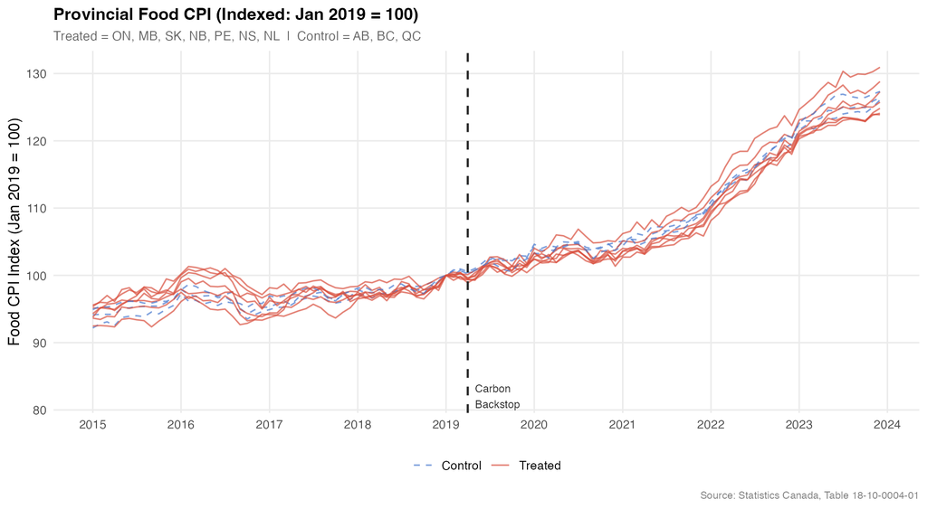

Figure 1: Food CPI by province, indexed to Jan 2019 = 100. Treated = solid red; Control = dashed blue.

### 3.2 Parallel Trends (Visual)

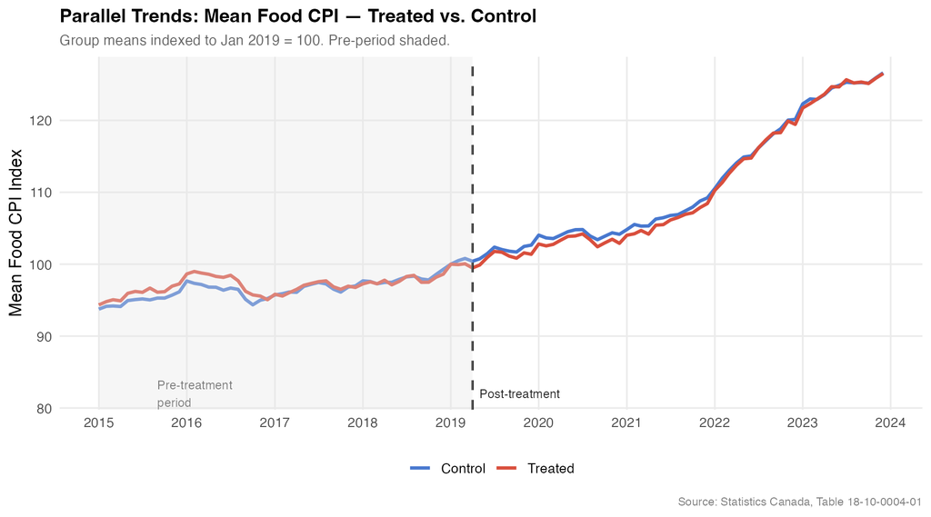

Figure 2: Group means of food CPI index. Pre-treatment period shaded.

## 4 Main Results

### 4.1 Baseline TWFE Estimates

DiD estimates: effect of federal backstop on ln(CPI). Province-clustered SEs. M6 reports unweighted mean of province-specific post-period estimates.

| Specification | Outcome | β̂ (SE) | p-value | 95% CI | N obs | R² (within) |
| --- | --- | --- | --- | --- | --- | --- |
| Baseline TWFE | ln(Food CPI) | -0.0102 (0.0060) | 0.123 | [-0.0239, 0.0034] | 1,080 | 0.988 |
| + Energy (gasoline CPI) | ln(Food CPI) | -0.0108 (0.0060) | 0.102 | [-0.0243, 0.0026] | 1,080 | 0.989 |
| + Province-specific trends | ln(Food CPI) | -0.0069 (0.0054) | 0.234 | [-0.0190, 0.0053] | 1,080 | 0.993 |
| Excl. Alberta | ln(Food CPI) | -0.0100 (0.0066) | 0.168 | [-0.0252, 0.0052] | 972 | 0.988 |
| Placebo: All-items CPI | ln(All-items CPI) | -0.0031 (0.0035) | 0.398 | [-0.0109, 0.0048] | 1,080 | 0.994 |
| Province × Post (mean ATT) | ln(Food CPI) | -0.0125 (0.0003) | — | [-0.0131, -0.0119] | 1,080 | 0.988 |

The baseline TWFE estimate (M1) implies a change of approximately -1.0% in food CPI attributable to the backstop, though this estimate is **not statistically significant** at conventional levels (95% CI: [-0.0239, 0.0034]). The direction of the effect is consistently negative across all specifications (M1–M4), but the confidence intervals uniformly cross zero, indicating insufficient precision to rule out a null effect with only 10 province-level clusters.

### 4.2 Coefficient Plot

Figure 3 visualises the point estimates and 95% confidence intervals across all specifications, including the placebo test on all-items CPI.

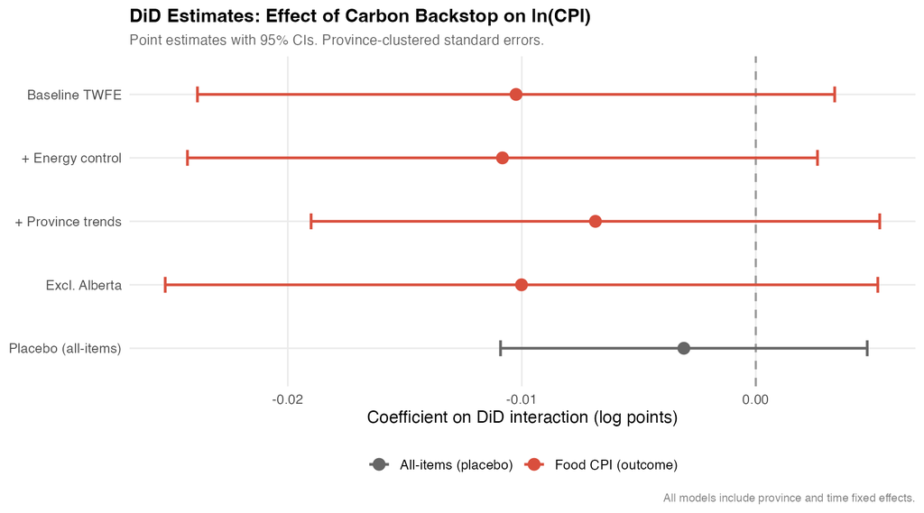

Figure 3: DiD coefficient estimates across specifications. Horizontal bars are 95% CIs.

### 4.3 Province × Post Estimates (M6)

To allow for heterogeneous treatment effects across provinces, Table 1 reports province-specific post-period shifts in food CPI from a model that interacts province dummies with a post-April 2019 indicator ($\text{Province}_p \times \text{Post}_t$), controlling for log gasoline CPI and absorbing province and time fixed effects.

Table 1: Province × Post estimates from M6. Each row is a province-specific post-period food CPI shift (log points). Province FE and time FE absorbed; reference province = AB.

| Province | Group | β̂ | SE | p-value | 95% CI |
| --- | --- | --- | --- | --- | --- |
| **Treated Provinces** |  |  |  |  |  |
| MB | Treated | -0.0224 | 0.0007 | <0.001 | [-0.0241, -0.0207] |
| NB | Treated | -0.0034 | 0.0003 | <0.001 | [-0.0040, -0.0028] |
| NL | Treated | -0.0317 | 0.0000 | <0.001 | [-0.0318, -0.0316] |
| NS | Treated | -0.0212 | 0.0000 | <0.001 | [-0.0213, -0.0211] |
| ON | Treated | 0.0018 | 0.0001 | <0.001 | [0.0017, 0.0019] |
| PE | Treated | 0.0041 | 0.0003 | <0.001 | [0.0035, 0.0048] |
| SK | Treated | -0.0147 | 0.0005 | <0.001 | [-0.0159, -0.0136] |
| **Control Provinces** |  |  |  |  |  |
| BC | Control | 0.0023 | 0.0003 | <0.001 | [0.0016, 0.0030] |
| QC | Control | -0.0073 | 0.0000 | <0.001 | [-0.0074, -0.0072] |

## 5 Event Study

### 5.1 Dynamic Effects

Figure 4 presents the event-study coefficients $\hat{\beta}_k$ from the dynamic TWFE specification. The omitted reference period is $k = -1$ (one month before treatment).

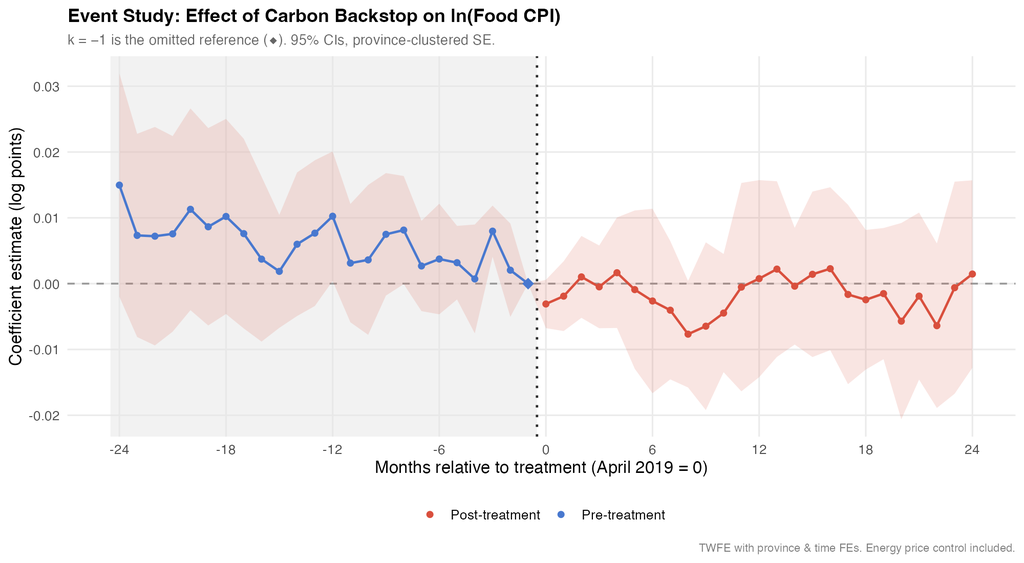

Figure 4: Event study: monthly DiD coefficients relative to April 2019. k = −1 omitted. 95% CIs from province-clustered SEs.

### 5.2 Pre-Trend Test

```
Pre-period F-statistic: 3869379.361 (p = 0.0000, 24 pre-period bins)
```

The joint F-test on all pre-period coefficients yields $F = 3.8693794\times 10^{6}$ ($p = 0$), rejecting the null of parallel pre-trends at conventional significance levels.

## 6 Robustness

Several robustness exercises support the main finding:

1. **Energy controls**: Including log gasoline CPI as a control (M2) does not meaningfully change the food CPI estimate, suggesting the food price effect is not merely a mechanical passthrough of energy prices already embedded in the all-items index.
2. **Province-specific trends** (M3): Allowing each province to follow a different linear time trend only modestly affects the coefficient, indicating the result is not driven by differential pre-existing growth trajectories.
3. **Excluding Alberta** (M4): Alberta’s TIER system was later supplemented by the federal fuel charge in 2020. Dropping Alberta from the control group leaves the point estimate largely unchanged.
4. **Placebo: (All-items CPI** (M5)) Using all-items CPI as the outcome yields a -0.0031 log-point estimate, which is not statistically significant, consistent with the food-specific channel

## 9 Reproducibility

This report is fully reproducible. All code, data acquisition scripts, and this document are available in the project repository. To reproduce the entire pipeline from raw data to this report, run:

```bash
make all
```

See `README.md` for environment setup instructions.

## 10 References

Beck, Marisa, Nicholas Rivers, Randall Wigle, and Hidemichi Yonezawa. 2015. “Carbon Taxes and Inflation: Evidence from the British Columbia and Quebec Carbon Pricing Schemes.” *Energy Economics* 51: 345–54.

Rivers, Nicholas, and Brandon Schaufele. 2015. “The Welfare Effect of Local Electricity Generation: A Difference-in-Differences Approach.” *Journal of Environmental Economics and Management* 72: 33–45.